# Task 4

Paulius Kostickis

Friday, March 11, 2016

Aplanke task4 yra duomenų failas, kuriame rasite nekilnojamo turto (o tiksliau gyvenaųjų būtų) kainas ir kaikurias jų charakteristikas. Užduotis atlikti išsamią tiesinę regresiją. Lygtis reikalinga prekyboms agentams, kad geriau suprastų kokią įtaką skirtingos charakteristikos daro galutinei kainai.

```r
library(lmtest)
library(car)                      #uzkraunamos reikalingos bibliotekos
library(knitr)
```

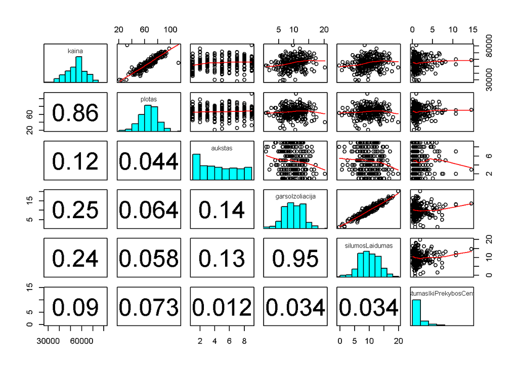

```r
data=read.csv2("data.csv")        #nuskaitomi duomenys

panel.hist <- function(x, ...)    #ši funkcija reikalinga grafikų lentelei išbrėžti (histogramos pateikimui)
{
  usr <- par("usr"); on.exit(par(usr))
  par(usr = c(usr[1:2], 0, 1.5) )
  h <- hist(x, plot = FALSE)
  breaks <- h$breaks; nB <- length(breaks)
  y <- h$counts; y <- y/max(y)
  rect(breaks[-nB], 0, breaks[-1], y, col = "cyan", ...)
}

panel.cor <- function(x, y, digits = 2, prefix = "", cex.cor,...)    #ši funkcija reikalinga grafikų lentelei
    #išbrėžti (koreliacijos koeficiento radimui)
{
  usr <- par("usr"); on.exit(par(usr))
  par(usr = c(0, 1, 0, 1))
  r <- abs(cor(x, y))
  txt <- format(c(r, 0.123456789), digits = digits)[1]
  txt <- paste0(prefix, txt)
  if(missing(cex.cor)) cex.cor <- 0.8/strwidth(txt)
  text(0.5, 0.5, txt, cex = 3)
}

pairs(data,upper.panel=panel.smooth,diag.panel=panel.hist, lower.panel=panel.cor)
```

```r
   #grafikų, histogramos ir koreliacijos lentelės, kuriomis parodomas bendras vaizdas
```

Iš lentelių matomas akivaizdus tiesinis ryšys tarp nekilnojamo turto ploto ir jo kainos, kiti poveikiai kainai nėra tokie akivaizdūs, tačiau matomas taip pat akivaizdus tiesinis ryšys tarp garso izoliacijos ir silumos laidumo, jų koreliacija 0,95.

Toliau panaikiname išskirtis iš duomenų (funkcijos idėja gauta iš http://stackoverflow.com/questions/4787332/how-to-remove-outliers-from-a-dataset)

```r
remove_outliers <- function(x) {
  qnt <- quantile(x, probs=c(.25, .75), na.rm = T)       #na.rm logical; if true, any NA and NaN's are removed
   #from x before the quantiles are computed.  Randami 25% ir 75% kvantiliai
  H <- 1.5 * IQR(x, na.rm = T)      #randamas atstumas, kurį reikia pridėti prie 75% kvantilio ir atimti iš
   #25% kvantilio, kad rasti ribą, nuo kurio galime teigti, kad duomenys už tos ribos bus išskirtys.
  y <- x
  y[x < (qnt[1] - H)] <- NA                  # duomenys, peržengiančios nustatytą ribą ir yra pakaičiami į NA
  y[x > (qnt[2] + H)] <- NA
  return(y)
}
data[1:4]=lapply(data[1:4],remove_outliers)          # ieškoma išskirtys tik keturiose stulpeliuose, nes kaip
                                                  # vėliau pamatysime, tik keturi stulpeliai mums reikalingi


row.has.na <- apply(data, 1, function(x){any(is.na(x))})    #tikrina visas duomenų eilutes ir jei randa
    #ištrintą reikšmę (t.y. pakeistą į NA), tada pažymime, kad ta eilutė turi išskirtį
data<- data[!row.has.na,]    #perankame duomenų eilutes, kurios neturi išskirčių
```

Modelių kūrimas

```r
mod=lm(kaina~plotas + aukstas+garsoIzoliacija+silumosLaidumas+atstumasIkiPrekybosCentro,data=data)
kable(summary(mod)$coef, digits=2) # du nereiksmingus rodo
```

|  | Estimate | Std. Error | t value | Pr(>\|t\|) |
| --- | --- | --- | --- | --- |
| (Intercept) | 7200.66 | 1046.70 | 6.88 | 0.00 |
| plotas | 604.06 | 13.08 | 46.19 | 0.00 |
| aukstas | 343.28 | 62.89 | 5.46 | 0.00 |
| garsoIzoliacija | 453.52 | 166.05 | 2.73 | 0.01 |
| silumosLaidumas | 103.50 | 155.42 | 0.67 | 0.51 |
| atstumasIkiPrekybosCentro | 83.26 | 79.98 | 1.04 | 0.30 |

```r
resettest(mod,power=2:3,type="regressor")$p.value   #nereikia kelti laipsniais kintamuosius, nes p reikšmė < 0,05
```

```
## [1] 9.137103e-12
```

Tikriname ir sprendžiame kolinearumo problemą:

```r
vif(mod)   # kolinearumo problema su šilumos ir garso laidumu
```

```
##                    plotas                   aukstas
##                  1.012887                  1.020416
##           garsoIzoliacija           silumosLaidumas
##                 10.797031                 10.736905
## atstumasIkiPrekybosCentro
##                  1.005235
```

```r
cor(data$garsoIzoliacija,data$silumosLaidumas) #kadangi ju koreliacija arti vieneto, galime viena
```

```
## [1] 0.9521586
```

```r
# kolinearumo problema su šilumos ir garso laidumu kintamaji tiesiog išmest (When the correlation between x1 and x2 is exactly one, the situation is
#called perfect collinearity, and one covariate needs to be removed from the regression model in order
#to estimate a solution. Šaltinis: http://www.nature.com/bdj/journal/v199/n7/full/4812743a.html)


mod2=lm(kaina~plotas +aukstas+garsoIzoliacija,data=data) #antras modelis, kuriame buvo išmesti nereikšmingi duomenys.
kable(summary(mod2)$coef, digits=2) # visi reikšmingi
```

|  | Estimate | Std. Error | t value | Pr(>\|t\|) |
| --- | --- | --- | --- | --- |
| (Intercept) | 7262.33 | 1043.47 | 6.96 | 0 |
| plotas | 604.63 | 13.03 | 46.41 | 0 |
| aukstas | 344.65 | 62.78 | 5.49 | 0 |
| garsoIzoliacija | 560.14 | 50.96 | 10.99 | 0 |

Lyginame mod ir mod2 modelius pagal AIC(“Akaike’s Information Criteria”) kriterijų. mod2 turi mažesnį AIC, taip pat yra paprastesnis ir be stipriai tarpusavyje koreliuotų kintamųjų, todėl mod2 geresnis:

```r
AIC(mod)
```

```
## [1] 4574.355
```

```r
AIC(mod2)
```

```
## [1] 4571.914
```

Tikriname modelio išskirtis:

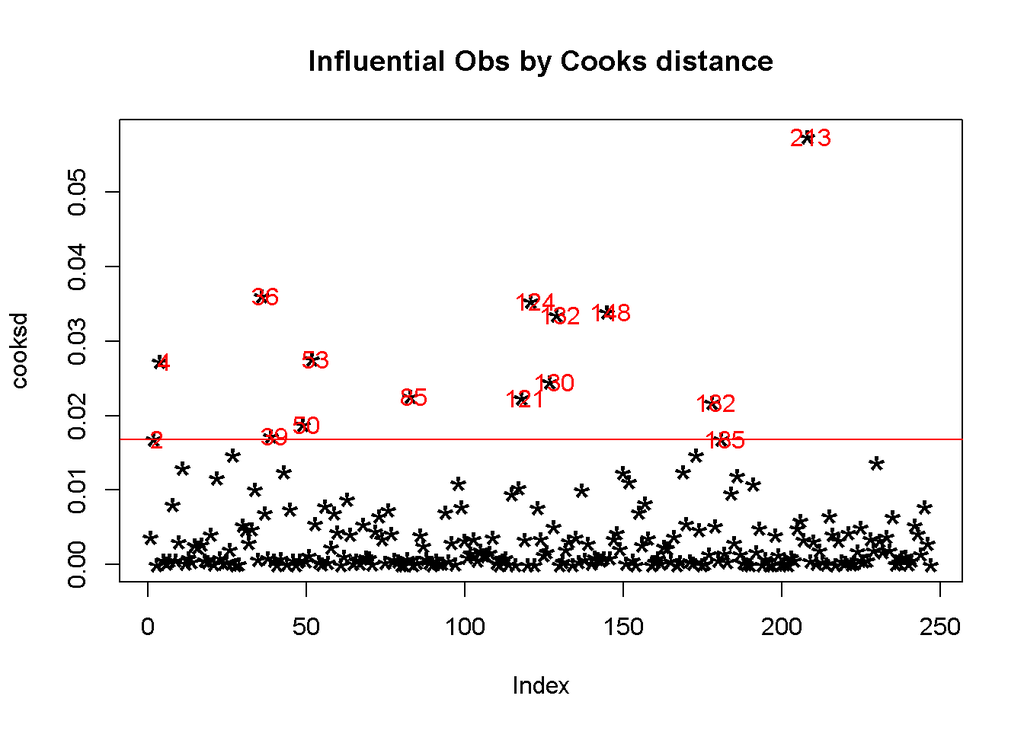

```r
#pastaba: užmiršau išsaugoti šaltinio šio kodo, radau internete
cooksd <- cooks.distance(mod2)
plot(cooksd, pch="*", cex=2, main="Influential Obs by Cooks distance")  # išbraižome cook'o distancija
abline(h = 4*mean(cooksd), col="red")  # nubrėžiame liniją, nuo kurios šalinsime išskirtis
text(x=1:length(cooksd)+1, y=cooksd, labels=ifelse(cooksd>4*mean(cooksd, na.rm=T),names(cooksd),""), col="red")
```

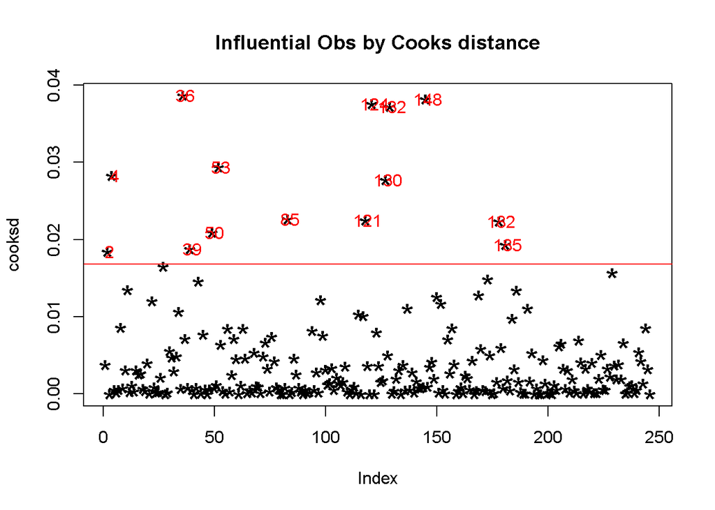

```r
# pavadiname išskirčių taškus, nurodome jų duomenų vietas
data=data[-c(208),]#naikiname vieną išskirtį (numeris ir jo padėtis duomenyse nesutapo dėl ankstesnio
                   #duomenių naikinimo)

mod2=lm(kaina~plotas +aukstas+garsoIzoliacija,data=data) #antras modelis, jau su išmesta išskirtimi.

cooksd <- cooks.distance(mod2)
plot(cooksd, pch="*", cex=2, main="Influential Obs by Cooks distance")  # išbraižome cook'o distancija
abline(h = 4*mean(cooksd), col="red")  # nubrėžiame liniją, nuo kurios šalinsime išskirtis
text(x=1:length(cooksd)+1, y=cooksd, labels=ifelse(cooksd>4*mean(cooksd, na.rm=T),names(cooksd),""), col="red")
```

```r
# pavadiname išskirčių taškus, nurodome jų duomenų vietas
```

Kadangi nekilnojimo turto aukštas yra ranginis kintamasis, naudosiu jį kaip dummy variable:

```r
aukstasn=factor(data$aukstas)   #aukšto skaičius paverčiamas į faktorių
mod3=lm(kaina~plotas +aukstasn+garsoIzoliacija,data=data)
kable(summary(mod3)$coef,digits=2)
```

|  | Estimate | Std. Error | t value | Pr(>\|t\|) |
| --- | --- | --- | --- | --- |
| (Intercept) | 4836.87 | 899.65 | 5.38 | 0 |
| plotas | 599.09 | 10.71 | 55.92 | 0 |
| aukstasn2 | 5022.27 | 547.97 | 9.17 | 0 |
| aukstasn3 | 4965.74 | 539.49 | 9.20 | 0 |
| aukstasn4 | 5584.07 | 547.57 | 10.20 | 0 |
| aukstasn5 | 4790.31 | 561.12 | 8.54 | 0 |
| aukstasn6 | 5430.52 | 572.69 | 9.48 | 0 |
| aukstasn7 | 4882.86 | 567.92 | 8.60 | 0 |
| aukstasn8 | 5537.64 | 582.33 | 9.51 | 0 |
| aukstasn9 | 4874.15 | 569.27 | 8.56 | 0 |
| garsoIzoliacija | 551.99 | 41.82 | 13.20 | 0 |

Matome, kad modelis pagerėjo iš AIC rodiklio:

```r
AIC(mod2)
```

```
## [1] 4542.041
```

```r
AIC(mod3)
```

```
## [1] 4460.691
```

Kadangi skirtumai tarp 2-9 aukštų yra labai maži, išskiriame tik 1 arba 2-9 aukštus (t.y. tikrinam tik ar nekilnojamas turtas pirmam aukšte ar ne pirmame) ir sukuriame mod4 modelį

```r
aukstas1=data$aukstas==1
mod4=lm(kaina~plotas +aukstas1+garsoIzoliacija,data=data)
kable(summary(mod4)$coef,digits=2)
```

|  | Estimate | Std. Error | t value | Pr(>\|t\|) |
| --- | --- | --- | --- | --- |
| (Intercept) | 9959.11 | 814.67 | 12.22 | 0 |
| plotas | 599.42 | 10.61 | 56.48 | 0 |
| aukstas1TRUE | -5129.45 | 422.62 | -12.14 | 0 |
| garsoIzoliacija | 550.59 | 41.20 | 13.37 | 0 |

Lyginame mod3 ir mod4, mod4 yra geresnis:

```r
AIC(mod3)
```

```
## [1] 4460.691
```

```r
AIC(mod4)
```

```
## [1] 4451.672
```

Homoskedastiškumo tikrinimas:

```r
bptest(mod4)            # neatmetam H0 hipotezės, kad homoskedastiškas. Reiškia galime teigti, homoskedastiškas
```

```
##
##  studentized Breusch-Pagan test
##
## data:  mod4
## BP = 1.7721, df = 3, p-value = 0.621
```

Autokoreliacijos tikrinimas:

```r
durbinWatsonTest(mod4)  # neatmetam H0 hipotezės, kad nėra autokoreliacijos. Autokoreliacijos nėra
```

```
##  lag Autocorrelation D-W Statistic p-value
##    1      0.04676158       1.90049   0.392
##  Alternative hypothesis: rho != 0
```

Taigi galutinis modelis:

```r
kable(summary(mod4)$coef,digits=2)
```

|  | Estimate | Std. Error | t value | Pr(>\|t\|) |
| --- | --- | --- | --- | --- |
| (Intercept) | 9959.11 | 814.67 | 12.22 | 0 |
| plotas | 599.42 | 10.61 | 56.48 | 0 |
| aukstas1TRUE | -5129.45 | 422.62 | -12.14 | 0 |
| garsoIzoliacija | 550.59 | 41.20 | 13.37 | 0 |

Už kiekvieną pločio arba garso izoliacijos rodiklio padidėjimą, kaina padidėja maždaug 600 vienetais. Jei nekilnojamas turtas pirmo aukšto, jo kaina maždaug sumažėja 5000 kainos vienetais.